# ExtraaLearn Project

Project developed by Anusha Sthanam

## Context

The EdTech industry has been surging in the past decade immensely, and according to a forecast, the Online Education market would be worth $286.62bn by 2023 with a compound annual growth rate (CAGR) of 10.26% from 2018 to 2023. The modern era of online education has enforced a lot in its growth and expansion beyond any limit. Due to having many dominant features like ease of information sharing, personalized learning experience, transparency of assessment, etc, it is now preferable to traditional education.

In the present scenario due to the Covid-19, the online education sector has witnessed rapid growth and is attracting a lot of new customers. Due to this rapid growth, many new companies have emerged in this industry. With the availability and ease of use of digital marketing resources, companies can reach out to a wider audience with their offerings. The customers who show interest in these offerings are termed as leads. There are various sources of obtaining leads for Edtech companies, like

- The customer interacts with the marketing front on social media or other online platforms.
- The customer browses the website/app and downloads the brochure
- The customer connects through emails for more information.

The company then nurtures these leads and tries to convert them to paid customers. For this, the representative from the organization connects with the lead on call or through email to share further details.

## Objective

ExtraaLearn is an initial stage startup that offers programs on cutting-edge technologies to students and professionals to help them upskill/reskill. With a large number of leads being generated on a regular basis, one of the issues faced by ExtraaLearn is to identify which of the leads are more likely to convert so that they can allocate resources accordingly. You, as a data scientist at ExtraaLearn, have been provided the leads data to:

- Analyze and build an ML model to help identify which leads are more likely to convert to paid customers,
- Find the factors driving the lead conversion process
- Create a profile of the leads which are likely to convert

## Data Description

The data contains the different attributes of leads and their interaction details with ExtraaLearn. The detailed data dictionary is given below.

**Data Dictionary**

- ID: ID of the lead
- age: Age of the lead
- current_occupation: Current occupation of the lead. Values include 'Professional','Unemployed',and 'Student'
- first_interaction: How did the lead first interacted with ExtraaLearn. Values include 'Website', 'Mobile App'
- profile_completed: What percentage of profile has been filled by the lead on the website/mobile app. Values include Low - (0-50%), Medium - (50-75%), High (75-100%)
- website_visits: How many times has a lead visited the website
- time_spent_on_website: Total time spent on the website
- page_views_per_visit: Average number of pages on the website viewed during the visits.
- last_activity: Last interaction between the lead and ExtraaLearn.
  - Email Activity: Seeking for details about program through email, Representative shared information with lead like brochure of program , etc
  - Phone Activity: Had a Phone Conversation with representative, Had conversation over SMS with representative, etc
  - Website Activity: Interacted on live chat with representative, Updated profile on website, etc
- print_media_type1: Flag indicating whether the lead had seen the ad of ExtraaLearn in the Newspaper.
- print_media_type2: Flag indicating whether the lead had seen the ad of ExtraaLearn in the Magazine.
- digital_media: Flag indicating whether the lead had seen the ad of ExtraaLearn on the digital platforms.
- educational_channels: Flag indicating whether the lead had heard about ExtraaLearn in the education channels like online forums, discussion threads, educational websites, etc.
- referral: Flag indicating whether the lead had heard about ExtraaLearn through reference.
- status: Flag indicating whether the lead was converted to a paid customer or not.

## Importing necessary libraries and data

```python
# To ignore warnings
import warnings
warnings.filterwarnings("ignore")
from statsmodels.tools.sm_exceptions import ConvergenceWarning
warnings.simplefilter("ignore", ConvergenceWarning)

# Libraries to help with reading and manipulating data
import pandas as pd
import numpy as np

# Libraries to help with data visualization
import matplotlib.pyplot as plt
import seaborn as sns

# Removes the limit for the number of displayed columns
pd.set_option("display.max_columns", None)
# Sets the limit for the number of displayed rows
pd.set_option("display.max_rows", 200)
# setting the precision of floating numbers to 5 decimal points
pd.set_option("display.float_format", lambda x: "%.5f" % x)
# To remove the scientific notation from the data
pd.set_option('display.float_format', '{:.2f}'.format)

# To scale the data using z-score
from sklearn.preprocessing import StandardScaler

# Library to split data
from sklearn.model_selection import train_test_split

# Algorithms to use
from sklearn.linear_model import LogisticRegression
from sklearn.svm import SVC
from sklearn.tree import DecisionTreeClassifier
from sklearn.ensemble import BaggingClassifier
from sklearn.ensemble import RandomForestClassifier
from sklearn import tree

# Metrics to evaluate the model
import sklearn.metrics as metrics
from sklearn.metrics import (
    f1_score,
    accuracy_score,
    recall_score,
    precision_score,
    confusion_matrix,
    classification_report,
    roc_auc_score,
    precision_recall_curve,
    roc_curve,
    make_scorer,
)

# For tuning the model
from sklearn.model_selection import GridSearchCV
```

# Loading Dataset

```python
#from google.colab import drive
#drive.mount('/content/drive')
```

```python
df = pd.read_csv('ExtraaLearn.csv')
```

## Data Overview

- Observations
- Sanity checks

```python
# Let's create a copy of the data
data = df.copy()
```

```python
data.head()
```

|  | ID | age | current_occupation | first_interaction | profile_completed | website_visits | time_spent_on_website | page_views_per_visit | last_activity | print_media_type1 | print_media_type2 | digital_media | educational_channels | referral | status |
| --- | --- | --- | --- | --- | --- | --- | --- | --- | --- | --- | --- | --- | --- | --- | --- |
| 0 | EXT001 | 57 | Unemployed | Website | High | 7 | 1639 | 1.86 | Website Activity | Yes | No | Yes | No | No | 1 |
| 1 | EXT002 | 56 | Professional | Mobile App | Medium | 2 | 83 | 0.32 | Website Activity | No | No | No | Yes | No | 0 |
| 2 | EXT003 | 52 | Professional | Website | Medium | 3 | 330 | 0.07 | Website Activity | No | No | Yes | No | No | 0 |
| 3 | EXT004 | 53 | Unemployed | Website | High | 4 | 464 | 2.06 | Website Activity | No | No | No | No | No | 1 |
| 4 | EXT005 | 23 | Student | Website | High | 4 | 600 | 16.91 | Email Activity | No | No | No | No | No | 0 |

```python
data.tail()
```

|  | ID | age | current_occupation | first_interaction | profile_completed | website_visits | time_spent_on_website | page_views_per_visit | last_activity | print_media_type1 | print_media_type2 | digital_media | educational_channels | referral | status |
| --- | --- | --- | --- | --- | --- | --- | --- | --- | --- | --- | --- | --- | --- | --- | --- |
| 4607 | EXT4608 | 35 | Unemployed | Mobile App | Medium | 15 | 360 | 2.17 | Phone Activity | No | No | No | Yes | No | 0 |
| 4608 | EXT4609 | 55 | Professional | Mobile App | Medium | 8 | 2327 | 5.39 | Email Activity | No | No | No | No | No | 0 |
| 4609 | EXT4610 | 58 | Professional | Website | High | 2 | 212 | 2.69 | Email Activity | No | No | No | No | No | 1 |
| 4610 | EXT4611 | 57 | Professional | Mobile App | Medium | 1 | 154 | 3.88 | Website Activity | Yes | No | No | No | No | 0 |
| 4611 | EXT4612 | 55 | Professional | Website | Medium | 4 | 2290 | 2.08 | Phone Activity | No | No | No | No | No | 0 |

```python
data.info()
```

```
<class 'pandas.core.frame.DataFrame'>
RangeIndex: 4612 entries, 0 to 4611
Data columns (total 15 columns):
 #   Column                 Non-Null Count  Dtype
---  ------                 --------------  -----
 0   ID                     4612 non-null   object
 1   age                    4612 non-null   int64
 2   current_occupation     4612 non-null   object
 3   first_interaction      4612 non-null   object
 4   profile_completed      4612 non-null   object
 5   website_visits         4612 non-null   int64
 6   time_spent_on_website  4612 non-null   int64
 7   page_views_per_visit   4612 non-null   float64
 8   last_activity          4612 non-null   object
 9   print_media_type1      4612 non-null   object
 10  print_media_type2      4612 non-null   object
 11  digital_media          4612 non-null   object
 12  educational_channels   4612 non-null   object
 13  referral               4612 non-null   object
 14  status                 4612 non-null   int64
dtypes: float64(1), int64(4), object(10)
memory usage: 540.6+ KB
```

**Observations:**

- There are **4612 observations and 15 columns** in the dataset.
- All the columns have 4612 non-null values, i.e., **there are no missing values in the data.**

**Let's check the unique values in each column**

```python
data.nunique()
```

```
ID                       4612
age                        46
current_occupation          3
first_interaction           2
profile_completed           3
website_visits             27
time_spent_on_website    1623
page_views_per_visit     2414
last_activity               3
print_media_type1           2
print_media_type2           2
digital_media               2
educational_channels        2
referral                    2
status                      2
dtype: int64
```

**Observations**

- ID is an identifier which is unique for each customer and we can drop this column as it would not add any value to our analysis.
- On the basis of number of unique values in each column and the data description, we can identify the continuous and categorical columns in the data.

```python
# Dropping the columns
data=data.drop(['ID'],axis=1)
```

```python
#Checking for any duplicates again and dropping them
data.duplicated().sum()
data.drop_duplicates(inplace=True, keep='first')
```

```python
data.info()
```

```
<class 'pandas.core.frame.DataFrame'>
Index: 4598 entries, 0 to 4611
Data columns (total 14 columns):
 #   Column                 Non-Null Count  Dtype
---  ------                 --------------  -----
 0   age                    4598 non-null   int64
 1   current_occupation     4598 non-null   object
 2   first_interaction      4598 non-null   object
 3   profile_completed      4598 non-null   object
 4   website_visits         4598 non-null   int64
 5   time_spent_on_website  4598 non-null   int64
 6   page_views_per_visit   4598 non-null   float64
 7   last_activity          4598 non-null   object
 8   print_media_type1      4598 non-null   object
 9   print_media_type2      4598 non-null   object
 10  digital_media          4598 non-null   object
 11  educational_channels   4598 non-null   object
 12  referral               4598 non-null   object
 13  status                 4598 non-null   int64
dtypes: float64(1), int64(4), object(9)
memory usage: 538.8+ KB
```

**Observations:**

- There are **4598 observations and 14 columns** in the dataset.
- All the columns have 4598 non-null values, i.e., **there are no missing values in the data.**

```python
# Creating numerical columns
num_cols=['age','website_visits','time_spent_on_website','page_views_per_visit','status']

# Creating categorical variables
cat_cols= ['current_occupation','first_interaction','profile_completed','last_activity','print_media_type1','print_media_type2','digital_media','educational_channels','referral']
```

## Exploratory Data Analysis (EDA)

- EDA is an important part of any project involving data.
- It is important to investigate and understand the data better before building a model with it.
- A few questions have been mentioned below which will help you approach the analysis in the right manner and generate insights from the data.
- A thorough analysis of the data, in addition to the questions mentioned below, should be done.

**Questions**

1. Leads will have different expectations from the outcome of the course and the current occupation may play a key role in getting them to participate in the program. Find out how current occupation affects lead status.
2. The company's first impression on the customer must have an impact. Do the first channels of interaction have an impact on the lead status?
3. The company uses multiple modes to interact with prospects. Which way of interaction works best?
4. The company gets leads from various channels such as print media, digital media, referrals, etc. Which of these channels have the highest lead conversion rate?
5. People browsing the website or mobile application are generally required to create a profile by sharing their personal data before they can access additional information.Does having more details about a prospect increase the chances of conversion?

### **Univariate analysis of numerical columns**

```python
# Checking summary statistics
data[num_cols].describe().T
```

|  | count | mean | std | min | 25% | 50% | 75% | max |
| --- | --- | --- | --- | --- | --- | --- | --- | --- |
| age | 4598.00 | 46.18 | 13.16 | 18.00 | 36.00 | 51.00 | 57.00 | 63.00 |
| website_visits | 4598.00 | 3.58 | 2.83 | 0.00 | 2.00 | 3.00 | 5.00 | 30.00 |
| time_spent_on_website | 4598.00 | 726.22 | 743.88 | 0.00 | 155.25 | 377.50 | 1341.75 | 2537.00 |
| page_views_per_visit | 4598.00 | 3.04 | 1.96 | 0.00 | 2.08 | 2.81 | 3.76 | 18.43 |
| status | 4598.00 | 0.30 | 0.46 | 0.00 | 0.00 | 0.00 | 1.00 | 1.00 |

**Observations**

**Let's explore these variables in some more depth by observing their distributions**

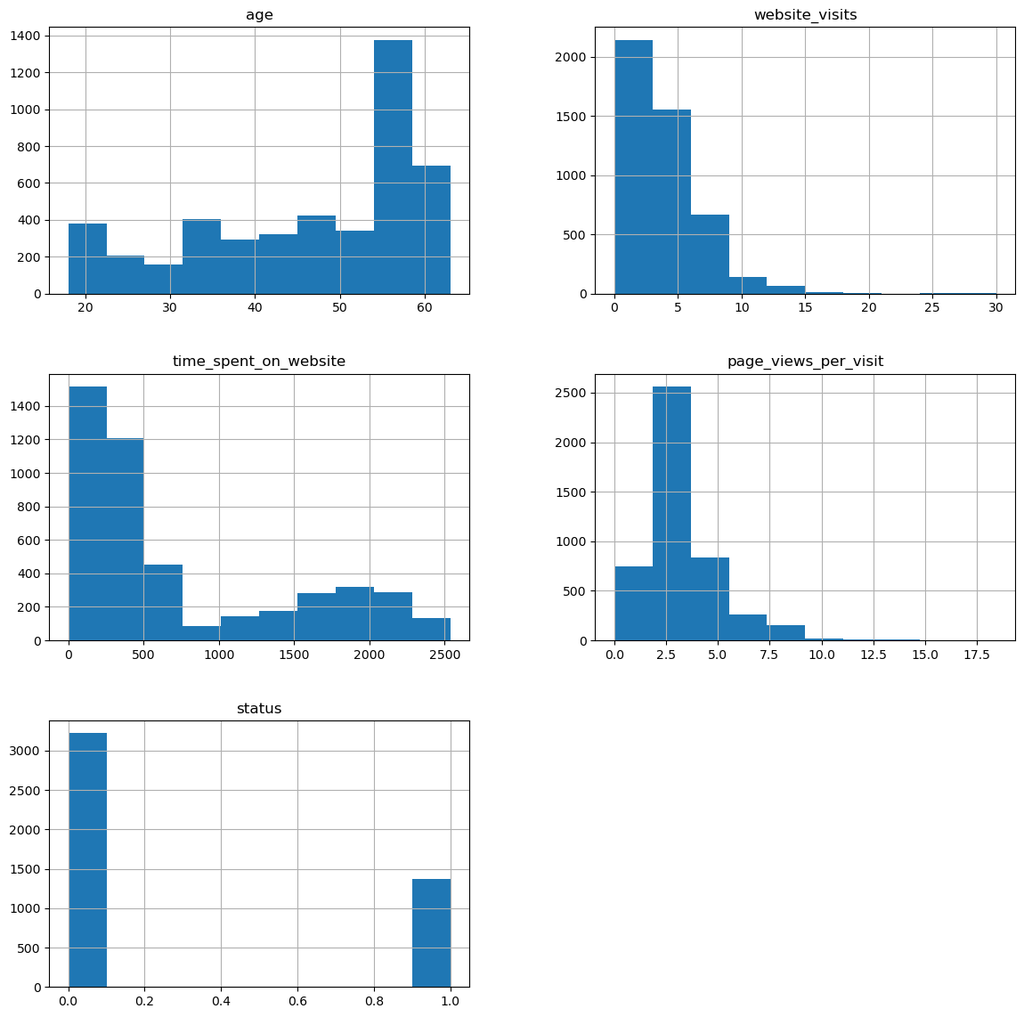

```python
# Creating histograms
data[num_cols].hist(figsize=(14,14))
plt.show()
```

**Observations:**

### **Univariate analysis for categorical variables**

```python
data.describe(include=["object"]).T
```

|  | count | unique | top | freq |
| --- | --- | --- | --- | --- |
| current_occupation | 4598 | 3 | Professional | 2608 |
| first_interaction | 4598 | 2 | Website | 2536 |
| profile_completed | 4598 | 3 | High | 2255 |
| last_activity | 4598 | 3 | Email Activity | 2269 |
| print_media_type1 | 4598 | 2 | No | 4102 |
| print_media_type2 | 4598 | 2 | No | 4365 |
| digital_media | 4598 | 2 | No | 4071 |
| educational_channels | 4598 | 2 | No | 3894 |
| referral | 4598 | 2 | No | 4505 |

**Observations:**

- Most of the Leads are Professional or Employed customers who are coming to upskill.
- Majority of the Leads are using website for interacting with ExtraaLearn

```python
# Printing the % sub categories of each category
for i in cat_cols:
    print(data[i].value_counts(normalize=True))
    print('*'*40)
```

```
current_occupation
Professional   0.57
Unemployed     0.31
Student        0.12
Name: proportion, dtype: float64
first_interaction
Website      0.55
Mobile App   0.45
Name: proportion, dtype: float64
profile_completed
High     0.49
Medium   0.49
Low      0.02
Name: proportion, dtype: float64
last_activity
Email Activity     0.49
Phone Activity     0.27
Website Activity   0.24
Name: proportion, dtype: float64
print_media_type1
No    0.89
Yes   0.11
Name: proportion, dtype: float64
print_media_type2
No    0.95
Yes   0.05
Name: proportion, dtype: float64
digital_media
No    0.89
Yes   0.11
Name: proportion, dtype: float64
educational_channels
No    0.85
Yes   0.15
Name: proportion, dtype: float64
referral
No    0.98
Yes   0.02
Name: proportion, dtype: float64
```

```python
# function to create labeled barplots

def labeled_barplot(data, feature, perc=False, n=None):
    """
    Barplot with percentage at the top

    data: dataframe
    feature: dataframe column
    perc: whether to display percentages instead of count (default is False)
    n: displays the top n category levels (default is None, i.e., display all levels)
    """

    total = len(data[feature])  # length of the column
    count = data[feature].nunique()
    if n is None:
        plt.figure(figsize=(count + 1, 5))
    else:
        plt.figure(figsize=(n + 1, 5))

    plt.xticks(rotation=90, fontsize=15)
    ax = sns.countplot(
        data=data,
        x=feature,
        palette="Paired",
        order=data[feature].value_counts().index[:n].sort_values(),
    )

    for p in ax.patches:
        if perc == True:
            label = "{:.1f}%".format(
                100 * p.get_height() / total
            )  # percentage of each class of the category
        else:
            label = p.get_height()  # count of each level of the category

        x = p.get_x() + p.get_width() / 2  # width of the plot
        y = p.get_height()  # height of the plot

        ax.annotate(
            label,
            (x, y),
            ha="center",
            va="center",
            size=12,
            xytext=(0, 5),
            textcoords="offset points",
        )  # annotate the percentage

    plt.show()  # show the plot
```

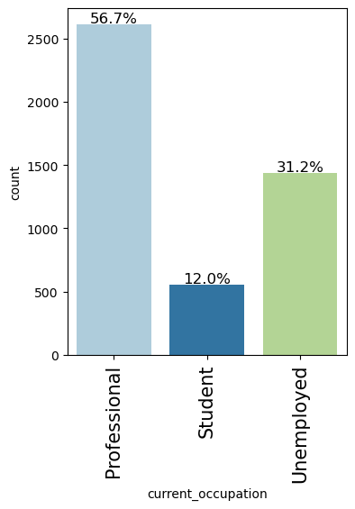

```python
# Observations on Current Occupation
labeled_barplot(data, "current_occupation", perc=True)
```

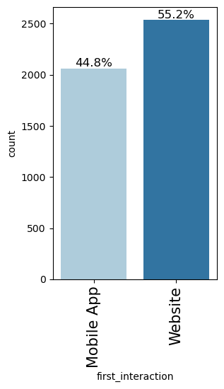

```python
#Observations on first_interaction
labeled_barplot(data, "first_interaction", perc=True)
```

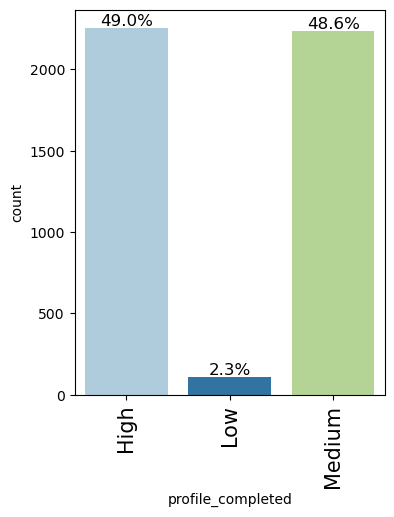

```python
#Observations on profile completed
labeled_barplot(data, "profile_completed", perc=True)
```

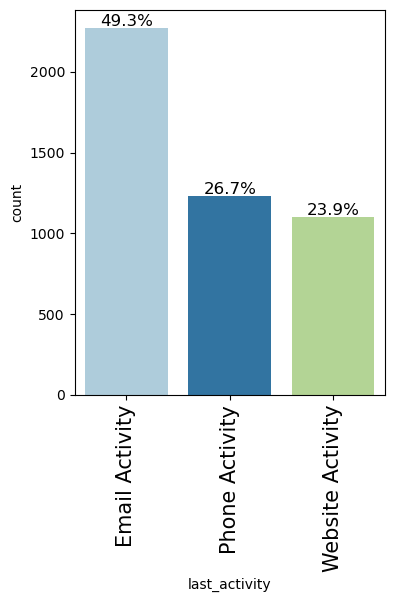

```python
### Observations on last_activity
labeled_barplot(data, "last_activity", perc=True)
```

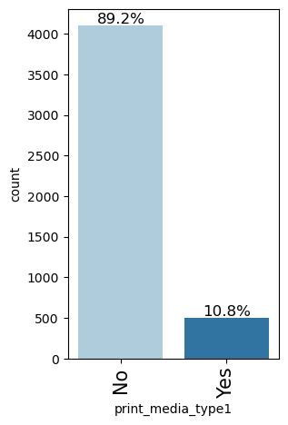

```python
### Observations on print_media_type1 - Newspapers
labeled_barplot(data, "print_media_type1", perc=True)
```

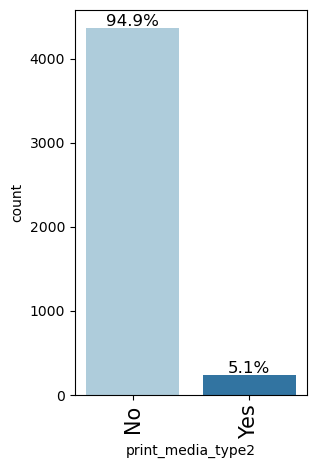

```python
### Observations on print_media_type2 - Magazines
labeled_barplot(data, "print_media_type2", perc=True)
```

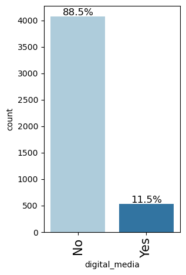

```python
#Observations on digital_media - online platforms
labeled_barplot(data, "digital_media", perc=True)
```

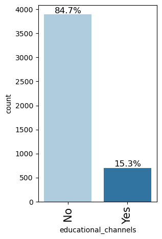

```python
#Observations on educational_channels
labeled_barplot(data, "educational_channels", perc=True)
```

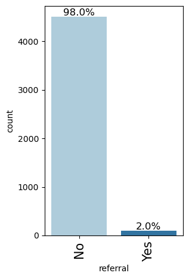

```python
#Observations on referral
labeled_barplot(data, "referral", perc=True)
```

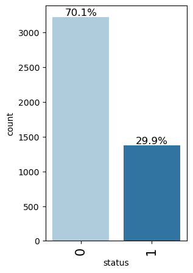

```python
#Observations on status
labeled_barplot(data, "status", perc=True)
```

**Observations:**

- 57% of **Professional**, 30% of unemployed Leads are very well interested in offerings of the ExtraaLearn. This plays a key role in getting them to participate in the program
- 55% of the Majority of the Leads are interacting the website using Website and 44% of the Leads are using Mobile App. So Website plays a keyrole in interaction.
- Majority of the Leads i.e. 95-96% of profiles have either completed their profiles or started filling up their information. This helps them to increase the chance of conversion by sending information to the prospect Leads.
- Around 50% of the Leads have Email activity, followed by 27% of phone activity and 24% of Website Activity for seeking more information about the program.
- 15% of the Leads have learned about ExtraaLearn from educational channels, so there is a chance of improvement.
- 11% of the Leads have learned about ExtraaLearn from Newspapers or digital platforms and very less consumption from Magazines i.e around 5%.
- 2% of the Leads are coming through Referral

### **Bivariate and Multivariate analysis**

We have analyzed different categorical and numerical variables. Let's now check how does status rate is related with other numerical variables.

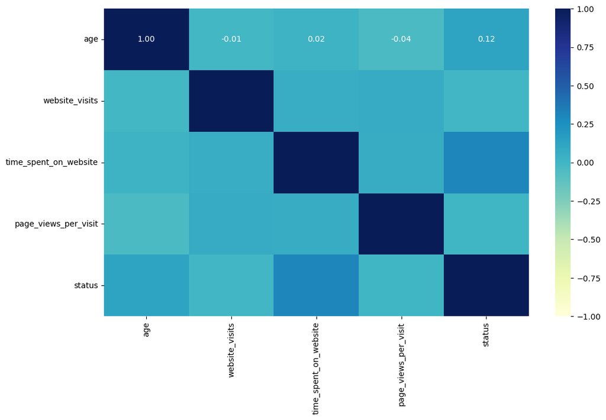

```python
# Plotting the correlation between numerical variables
plt.figure(figsize=(12,7))
sns.heatmap(df[num_cols].corr(),annot=True, fmt='0.2f', cmap='YlGnBu',vmin=-1, vmax=1)
plt.show()
```

**Observations:**

We will define a **stacked barplot()** function to help analyse how the target variable i.e. Status varies across other categories.

```python
# Defining the stacked_barplot() function
def stacked_barplot(data,predictor,target):
    """
    Print the category counts and plot a stacked bar chart

    data: dataframe
    predictor: independent variable
    target: target variable
    """
    count = data[predictor].nunique()
    sorter = data[target].value_counts().index[-1]
    tab1 = pd.crosstab(data[predictor], data[target], margins=True).sort_values(
        by=sorter, ascending=False
    )
    print()
    print(tab1)
    print()
    tab = pd.crosstab(data[predictor], data[target], normalize="index").sort_values(
        by=sorter, ascending=False
    )
    tab.plot(kind="bar", stacked=True, figsize=(count + 5, 5))
    plt.legend(
        loc="lower left", frameon=False,
    )
    plt.legend(loc="upper left", bbox_to_anchor=(1, 1))
    plt.show()
```

```python
print(data.columns)
```

```
Index(['age', 'current_occupation', 'first_interaction', 'profile_completed',
       'website_visits', 'time_spent_on_website', 'page_views_per_visit',
       'last_activity', 'print_media_type1', 'print_media_type2',
       'digital_media', 'educational_channels', 'referral', 'status'],
      dtype='object')
```

```
status                 0     1   All
current_occupation
All                 3223  1375  4598
Professional        1681   927  2608
Unemployed          1053   383  1436
Student              489    65   554
```

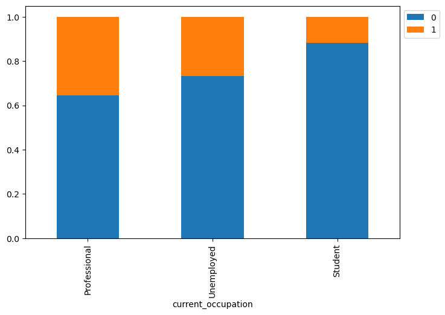

```
status                0     1   All
first_interaction
All                3223  1375  4598
Website            1379  1157  2536
Mobile App         1844   218  2062
```

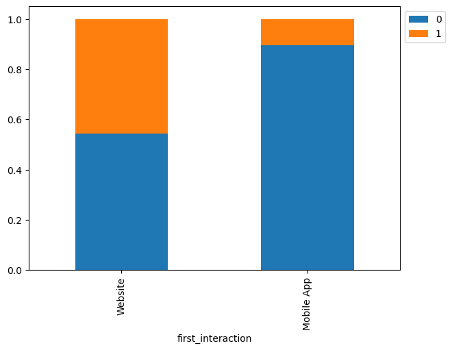

```
status                0     1   All
profile_completed
All                3223  1375  4598
High               1311   944  2255
Medium             1813   423  2236
Low                  99     8   107
```

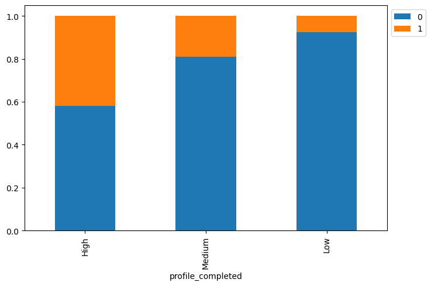

```
status               0     1   All
last_activity
All               3223  1375  4598
Email Activity    1579   690  2269
Website Activity   677   423  1100
Phone Activity     967   262  1229
```

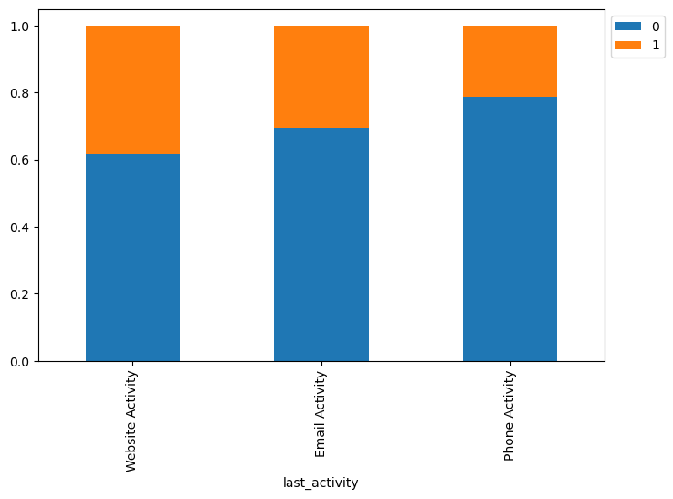

```
status                0     1   All
print_media_type1
All                3223  1375  4598
No                 2886  1216  4102
Yes                 337   159   496
```

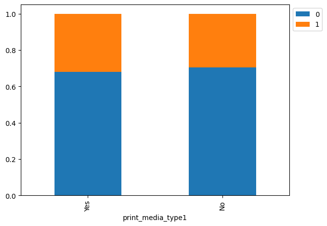

```
status                0     1   All
print_media_type2
All                3223  1375  4598
No                 3065  1300  4365
Yes                 158    75   233
```

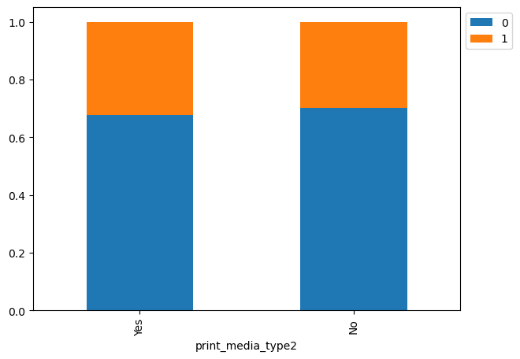

```
status            0     1   All
digital_media
All            3223  1375  4598
No             2864  1207  4071
Yes             359   168   527
```

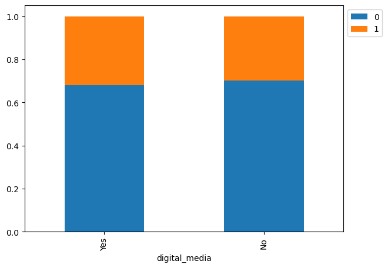

```
status                   0     1   All
educational_channels
All                   3223  1375  4598
No                    2716  1178  3894
Yes                    507   197   704
```

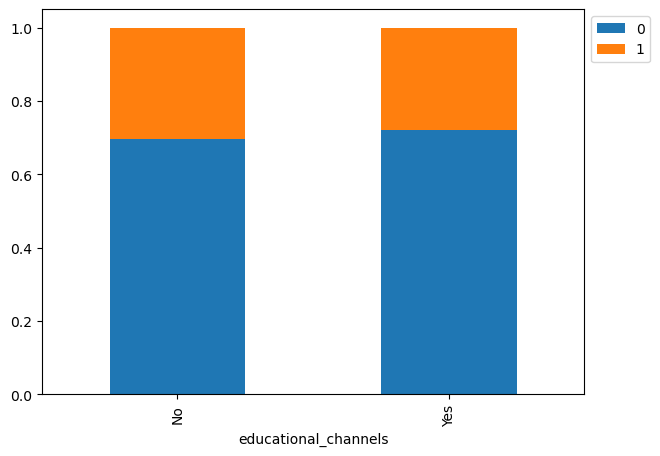

```
status       0     1   All
referral
All       3223  1375  4598
No        3193  1312  4505
Yes         30    63    93
```

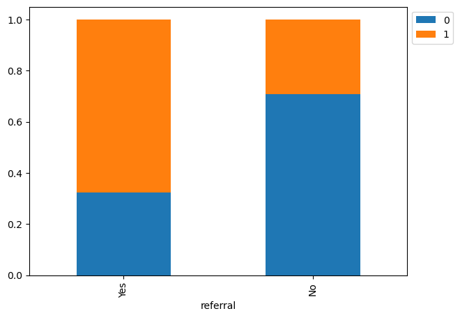

```python
for i in cat_cols:
 stacked_barplot(data, i, "status")
```

**Observations:**

- The company can target Professional and Unemployed Leads who has conversion rates of 36% and 26% respectively.
- The company has higher conversion rates in Website interaction of 45% followed by Mobile App by 10% respectively.
- Leads who are completing their profiles have higher conversion rates of 41% respectively.
- Leads who are referred have 68% chance of being paid customers.
- Leads who have interacted with Email or Website using Live chat have high chances of conversion with rates of 30% and 38% respectively.

### Outlier Check

- Let's check for outliers in the data.

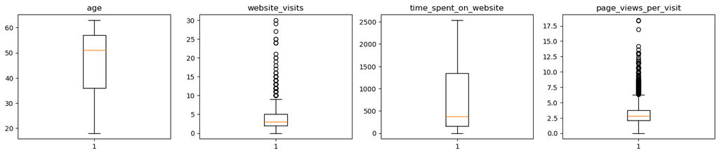

```python
# outlier detection using boxplot
numeric_columns = data.select_dtypes(include=np.number).columns.tolist()
# dropping release_year as it is a temporal variable
numeric_columns.remove("status")

plt.figure(figsize=(15, 12))

for i, variable in enumerate(numeric_columns):
    plt.subplot(4, 4, i + 1)
    plt.boxplot(data[variable], whis=1.5)
    plt.tight_layout()
    plt.title(variable)

plt.show()
```

```python
numeric_data = data.select_dtypes(include=['float64', 'int64'])

# Calculate quartiles and IQR
Q1 = numeric_data.quantile(0.25)
Q3 = numeric_data.quantile(0.75)
IQR = Q3 - Q1

# Find lower and upper bounds for outliers
lower = Q1 - 1.5 * IQR
upper = Q3 + 1.5 * IQR
```

```python
(
    (data.select_dtypes(include=["float64", "int64"]) < lower)
    | (data.select_dtypes(include=["float64", "int64"]) > upper)
).sum() / len(data) * 100
```

```
age                     0.00
website_visits          3.35
time_spent_on_website   0.00
page_views_per_visit    5.59
status                  0.00
dtype: float64
```

**Observations:**

- There are lot of outliers for Website_visits or pages viewed per visit.

Separating the independent variables (X) and the dependent variable (Y)

```python
# Separating target variable and other variables
X=data.drop(columns='status')
Y=data['status']

X = pd.get_dummies(X, drop_first=True) # Complete the code to get dummies for X

# Splitting the data in 70:30 ratio for train to test data
X_train, X_test, y_train, y_test = train_test_split(
    X, Y, test_size=0.30, random_state=1
)
```

```python
X_train.info()
```

```
<class 'pandas.core.frame.DataFrame'>
Index: 3218 entries, 2109 to 235
Data columns (total 16 columns):
 #   Column                          Non-Null Count  Dtype
---  ------                          --------------  -----
 0   age                             3218 non-null   int64
 1   website_visits                  3218 non-null   int64
 2   time_spent_on_website           3218 non-null   int64
 3   page_views_per_visit            3218 non-null   float64
 4   current_occupation_Student      3218 non-null   bool
 5   current_occupation_Unemployed   3218 non-null   bool
 6   first_interaction_Website       3218 non-null   bool
 7   profile_completed_Low           3218 non-null   bool
 8   profile_completed_Medium        3218 non-null   bool
 9   last_activity_Phone Activity    3218 non-null   bool
 10  last_activity_Website Activity  3218 non-null   bool
 11  print_media_type1_Yes           3218 non-null   bool
 12  print_media_type2_Yes           3218 non-null   bool
 13  digital_media_Yes               3218 non-null   bool
 14  educational_channels_Yes        3218 non-null   bool
 15  referral_Yes                    3218 non-null   bool
dtypes: bool(12), float64(1), int64(3)
memory usage: 163.4 KB
```

```python
print("Shape of Training set : ", X_train.shape)
print("Shape of test set : ", X_test.shape)
print("Percentage of classes in training set:")
print(y_train.value_counts(normalize=True))
print("Percentage of classes in test set:")
print(y_test.value_counts(normalize=True))
```

```
Shape of Training set :  (3218, 16)
Shape of test set :  (1380, 16)
Percentage of classes in training set:
status
0   0.70
1   0.30
Name: proportion, dtype: float64
Percentage of classes in test set:
status
0   0.71
1   0.29
Name: proportion, dtype: float64
```

## **Building Classification Models**

### Model evaluation criterion

### Model can make wrong predictions as:

1. Predicting a lead will not be converted to a paid customer in reality, the lead would have converted to a paid customer.
2. Predicting a lead will be converted to a paid customer in reality, the lead would not have converted to a paid customer.

**Observations**

- If we predict that a lead will not get converted and the lead would have converted then the company will lose a potential customer.

Hence Losing a potential customer is a greater loss.

- Company would want `Recall` to be maximized, greater the Recall score higher are the chances of minimizing False Negatives.

#### First, let's create functions to calculate different metrics and confusion matrix so that we don't have to use the same code repeatedly for each model.

```python
# Function to print the classification report and get confusion matrix in a proper format

def metrics_score(actual, predicted):
    print(classification_report(actual, predicted))

    cm = confusion_matrix(actual, predicted)

    plt.figure(figsize = (8, 5))

    sns.heatmap(cm, annot = True,  fmt = '.2f', xticklabels = ['Not Converted', 'Converted'], yticklabels = ['Not Converted', 'Converted'])

    plt.ylabel('Actual')

    plt.xlabel('Predicted')

    plt.show()
```

## Building a Decision Tree model

```python
d_tree = DecisionTreeClassifier(random_state=1)
d_tree.fit(X_train, y_train)
```

```
DecisionTreeClassifier(random_state=1)
```

#### Checking model performance on training set

```
              precision    recall  f1-score   support

           0       1.00      1.00      1.00      2243
           1       1.00      1.00      1.00       975

    accuracy                           1.00      3218
   macro avg       1.00      1.00      1.00      3218
weighted avg       1.00      1.00      1.00      3218
```

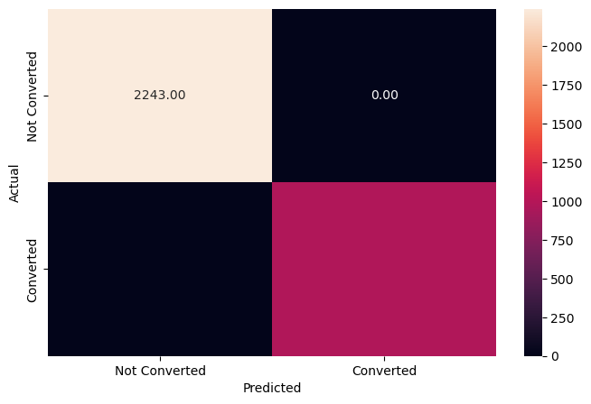

```python
# Checking performance on the training data
y_pred_train1 = d_tree.predict(X_train)
metrics_score(y_train, y_pred_train1)
```

Observations:

- Almost 0 errors on the training set, each sample has been classified correctly.
- Model has performed very well on the training set.

**Let's check the performance on test data to see if the model is overfitting.**

```
              precision    recall  f1-score   support

           0       0.85      0.84      0.85       980
           1       0.62      0.65      0.64       400

    accuracy                           0.78      1380
   macro avg       0.74      0.74      0.74      1380
weighted avg       0.79      0.78      0.79      1380
```

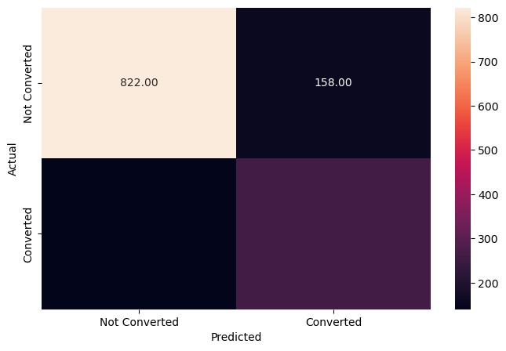

```python
# Checking performance on the testing data
y_pred_test1 = d_tree.predict(X_test)
metrics_score(y_test, y_pred_test1)
```

Observations:

- The recall is 0.65 on testing data and 1.0 on the training data, which indicates overfitting.
- We can try hyperparameter tuning using GridSearchCV to find the optimal max_depth** to reduce overfitting of the model.

## Do we need to prune the tree?

Yes, we can prune using Hyperparameter tuning.

```python
# Choose the type of classifier
d_tree_tuned = DecisionTreeClassifier(random_state = 7, class_weight = {0: 0.3, 1: 0.7})

# Grid of parameters to choose from
parameters = {'max_depth': np.arange(2, 10),
              'criterion': ['gini', 'entropy'],
              'min_samples_leaf': [5, 10, 20, 25]
             }

# Type of scoring used to compare parameter combinations - recall score for class 1
scorer = metrics.make_scorer(recall_score, pos_label = 1)

# Run the grid search
grid_obj = GridSearchCV(d_tree_tuned, parameters, scoring = scorer, cv = 5)

grid_obj = grid_obj.fit(X_train, y_train)

# Set the classifier to the best combination of parameters
d_tree_tuned = grid_obj.best_estimator_

# Fit the best algorithm to the data
d_tree_tuned.fit(X_train, y_train)
```

```
DecisionTreeClassifier(class_weight={0: 0.3, 1: 0.7}, criterion='entropy',
                       max_depth=3, min_samples_leaf=5, random_state=7)
```

We have tuned the model and fit the tuned model on the training data. Now, let's check the model performance on the training and testing data.

```
              precision    recall  f1-score   support

           0       0.95      0.74      0.83      2243
           1       0.61      0.91      0.73       975

    accuracy                           0.79      3218
   macro avg       0.78      0.83      0.78      3218
weighted avg       0.84      0.79      0.80      3218
```

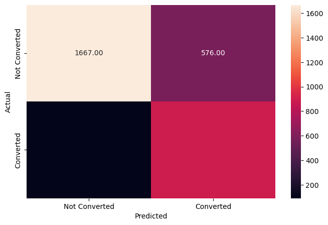

```python
# Checking performance on the training data
y_pred_train2 = d_tree_tuned.predict(X_train)
metrics_score(y_train, y_pred_train2)
```

**Observations:**

- Using this hyperparameter tuning, model is able to predict 91% of the recall, which is a very good score.

Let's check the model performance on the testing data

```
              precision    recall  f1-score   support

           0       0.94      0.73      0.82       980
           1       0.58      0.89      0.70       400

    accuracy                           0.78      1380
   macro avg       0.76      0.81      0.76      1380
weighted avg       0.83      0.78      0.79      1380
```

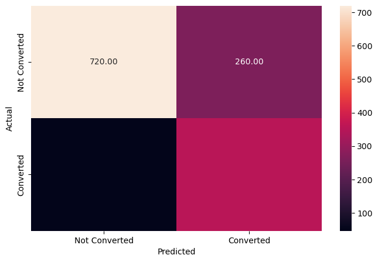

```python
# Checking performance on the testing data
y_pred_test2 = d_tree_tuned.predict(X_test)
metrics_score(y_test, y_pred_test2)
```

**Observations:**

**Let's visualize the tuned decision tree** and observe the decision rules:

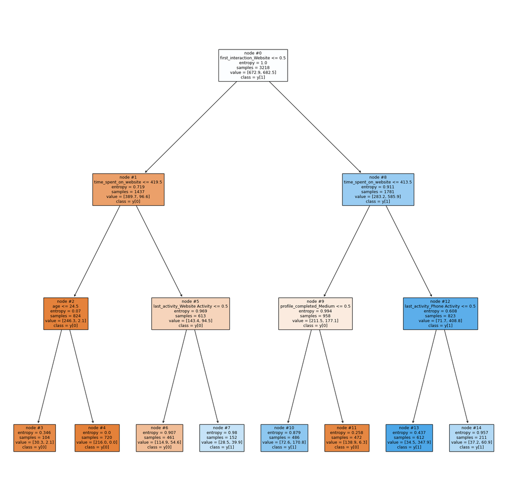

```python
features = list(X.columns)

plt.figure(figsize = (20, 20))

tree.plot_tree(d_tree_tuned, feature_names = features, filled = True, fontsize = 9, node_ids = True, class_names = True)

plt.show()
```

Let's look at the feature importance of the tuned decision tree model

```python
# Importance of features in the tree building

print (pd.DataFrame(d_tree_tuned.feature_importances_, columns = ["Imp"], index = X_train.columns).sort_values(by = 'Imp', ascending = False))
```

```
                                Imp
time_spent_on_website          0.35
first_interaction_Website      0.35
profile_completed_Medium       0.22
last_activity_Phone Activity   0.05
last_activity_Website Activity 0.02
age                            0.01
website_visits                 0.00
page_views_per_visit           0.00
current_occupation_Student     0.00
current_occupation_Unemployed  0.00
profile_completed_Low          0.00
print_media_type1_Yes          0.00
print_media_type2_Yes          0.00
digital_media_Yes              0.00
educational_channels_Yes       0.00
referral_Yes                   0.00
```

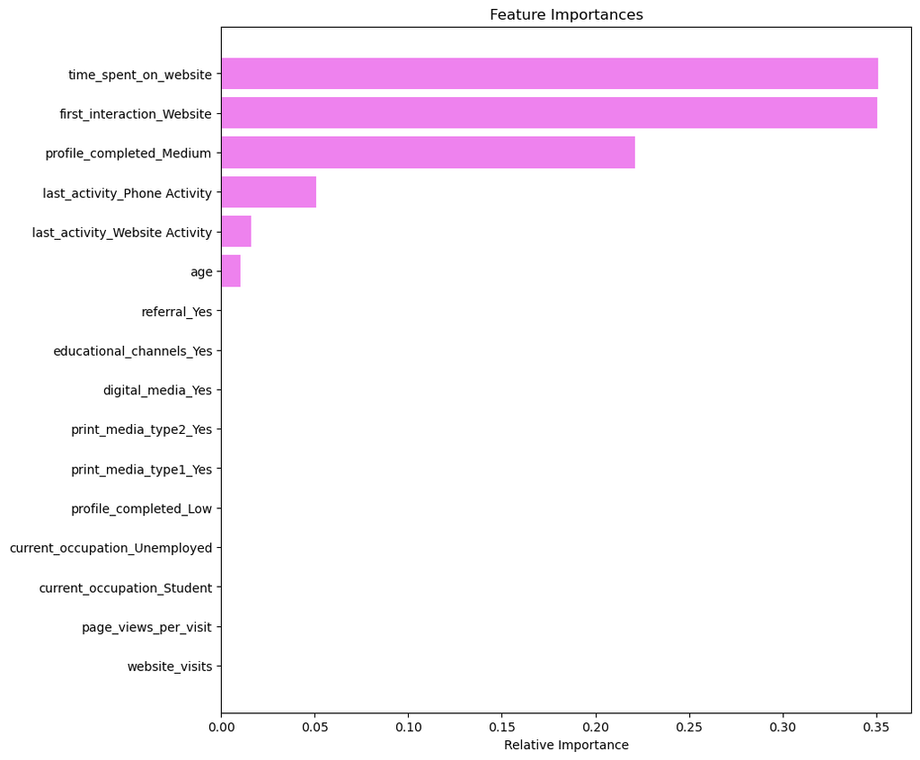

```python
# Plotting the feature importance
importances = d_tree_tuned.feature_importances_

indices = np.argsort(importances)

plt.figure(figsize = (10, 10))

plt.title('Feature Importances')

plt.barh(range(len(indices)), importances[indices], color = 'violet', align = 'center')

plt.yticks(range(len(indices)), [features[i] for i in indices])

plt.xlabel('Relative Importance')

plt.show()
```

**Observations:**

## Building a Random Forest model

```python
# Fitting the random forest tree classifier on the training data
rf_estimator = RandomForestClassifier(random_state = 1)
rf_estimator.fit(X_train, y_train)
```

```
RandomForestClassifier(random_state=1)
```

Let's check the performance of the model on the training data

```
              precision    recall  f1-score   support

           0       1.00      1.00      1.00      2243
           1       1.00      1.00      1.00       975

    accuracy                           1.00      3218
   macro avg       1.00      1.00      1.00      3218
weighted avg       1.00      1.00      1.00      3218
```

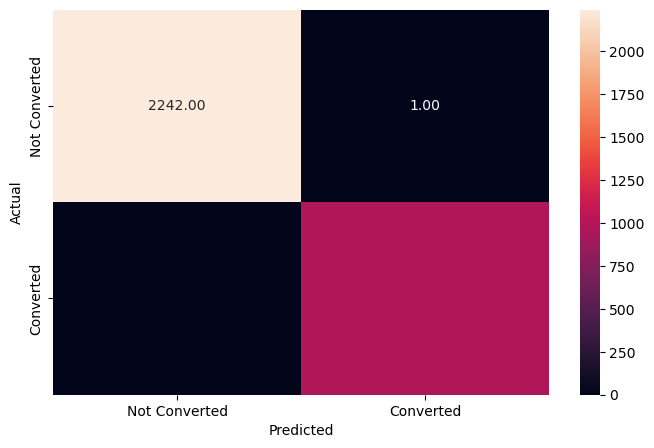

```python
y_pred_train3 = rf_estimator.predict(X_train)
metrics_score(y_train, y_pred_train3)
```

Observations:

- Almost 0 errors on the training set, each sample has been classified correctly.
- Model has performed very well on the training set.

**Let's check the performance on the testing data**

```
              precision    recall  f1-score   support

           0       0.88      0.91      0.89       980
           1       0.76      0.69      0.72       400

    accuracy                           0.85      1380
   macro avg       0.82      0.80      0.81      1380
weighted avg       0.84      0.85      0.84      1380
```

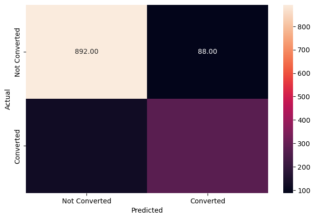

```python
# Checking performance on the testing data
y_pred_test3 = rf_estimator.predict(X_test)
metrics_score(y_test, y_pred_test3)
```

Observations:

We will **not** tune the `criterion` hyperparameter as we know from hyperparameter tuning for decision trees that `entropy` is a better splitting criterion for this data.

```python
# Choose the type of classifier
rf_estimator_tuned = RandomForestClassifier(criterion = "entropy", random_state = 7)

# Grid of parameters to choose from
parameters = {"n_estimators": [110, 120],
    "max_depth": [6, 7],
    "min_samples_leaf": [20, 25],
    "max_features": [0.8, 0.9],
    "max_samples": [0.9, 1],
    "class_weight": ["balanced",{0: 0.3, 1: 0.7}]
             }

# Type of scoring used to compare parameter combinations - recall score for class 1
scorer = metrics.make_scorer(recall_score, pos_label = 1)

# Run the grid search on the training data using scorer=scorer and cv=5
grid_obj = GridSearchCV(rf_estimator_tuned, parameters, scoring = scorer, cv = 5)

# Fit the grid search object to the training data and find the optimal parameters
grid_obj = grid_obj.fit(X_train, y_train)

# Save the best estimator to variable rf_estimator_tuned
rf_estimator_tuned = grid_obj.best_estimator_

# Fit the best algorithm to the data
rf_estimator_tuned.fit(X_train, y_train)
```

Checking the performance on the training data

```
              precision    recall  f1-score   support

           0       0.94      0.83      0.88      2243
           1       0.69      0.88      0.77       975

    accuracy                           0.85      3218
   macro avg       0.82      0.85      0.83      3218
weighted avg       0.87      0.85      0.85      3218
```

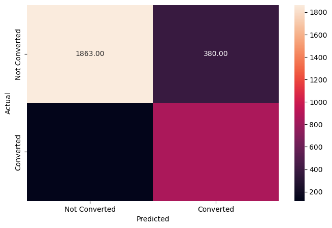

```python
y_pred_train4 = rf_estimator_tuned.predict(X_train)
metrics_score(y_train, y_pred_train4)
```

**Observations:**

- The Random forest Tuned model shows overall 88% on recall for the training data.
- The precision is 68% for the model.
- Accuracy of this model is 85%